# flexcure: an R package for parametric analysis of survival data with cure fraction

20 de maio de 2016

## Motivação

## Introdução

[figure not shown]

## Modelos de sobrevivência com fração de cura

## Noções preliminares

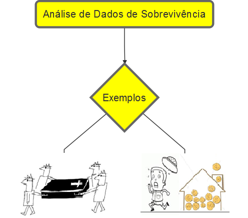

## Noções preliminares

> Seja \(T\) uma v.a. contínua não-negativa representando o tempo até a ocorrência de um particular evento de interesse, com função densidade de probabilidade \(f_{T}\left(t\right)\) e função de distribuição acumulada \(F_{T}\left(t\right)\). Define-se então,

### Função de sobrevivência

\[ S_{T}\left(t\right)=P\left(T\geq t\right)=1-F_{T}\left(t\right) \]

### Função de risco

\[ h\left(t\right)=\lim_{\triangle t\rightarrow0}\frac{P\left(t\leq T<t+\triangle t|T\geq t\right)}{\triangle t} = \frac{f_{T}\left(t\right)}{S_{T}\left(t\right)} \]

## Noções preliminares

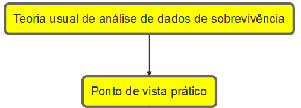

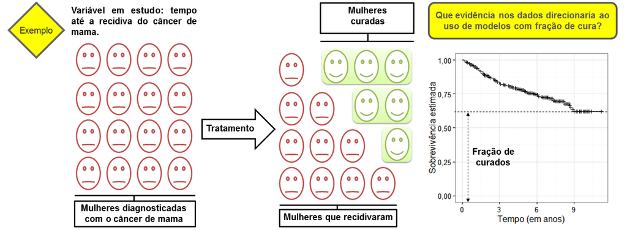

## Formulação da função de sobrevivência populacional

### Definições:

- Seja \(M\) uma v.a. representando o número de causas que podem levar a ocorrência de um determinado evento de interesse, com \(p_{\theta}\left(m\right)=P\left(M=m\right)\), \(m=0,1,\ldots\);
- Dado \(M=m\), define-se \(Z_{j}=\mu+\sigma W_{j}\), \(j=1,\ldots,m\) v.a. i.i.d que correspondem ao logaritmo do tempo até a ocorrência do evento para \(j\)-ésima causa, com função de densidade e sobrevivência de \(Z\) dada por:

\[ f_{Z}\left(z;\mu,\sigma,\boldsymbol{\xi}\right)=\frac{1}{\sigma}f_{W}\left(\frac{z-\mu}{\sigma};\boldsymbol{\xi}\right)\;\textrm{e}\; S_{Z}\left(z;\mu,\sigma,\boldsymbol{\xi}\right)=S_{W}\left(\frac{z-\mu}{\sigma};\boldsymbol{\xi}\right), \] no caso em que \(M=0\), diz-se que o elemento é imune ou curado, define-se \(Z_{0}\), tal que, a \(P\left(Z_{0}=\infty\right)=1\). Sendo \(M\) e \(Z_{j}\) variáveis latentes e assume-se que são independentes;

- Considere também que o logaritmo do tempo até a ocorrência do evento de interesse é dado por \(R=\min\left\{ Z_{0},Z_{1},\ldots,Z_{M}\right\}\).

## Formulação da função de sobrevivência populacional

### Função de sobrevivência populacional (RODRIGUES et al., 2009)

\[ \begin{align} S_{p}\left(r;\boldsymbol{\psi}\right) & = P\left(R>r\right) = \sum_{m=0}^{\infty}p_{\theta}\left(m\right)\left[S_{Z}\left(r;\mu,\sigma,\boldsymbol{\xi}\right)\right]^{m}\\ & = \pi+\sum_{m=1}^{\infty}p_{\theta}\left(m\right)\left[S_{Z}\left(r;\mu,\sigma,\boldsymbol{\xi}\right)\right]^{m} \end{align} \]

### Função de densidade populacional

\[ \begin{align} f_{p}\left(r;\boldsymbol{\psi}\right) & = -\frac{dS_{p}\left(r;\boldsymbol{\psi}\right)}{dr}\\ & = f_{Z}\left(r;\mu,\sigma,\boldsymbol{\xi}\right)\sum_{m=1}^{\infty}mp_{\theta}\left(m\right)\left[S_{Z}\left(r;\mu,\sigma,\boldsymbol{\xi}\right)\right]^{m-1} \end{align} \]

## Formulação da função de sobrevivência populacional

### Casos particulares:

- Modelo de mistura padrão (\(M\sim Bernoulli\left(1-\theta\right)\)) (BOAG, 1949 e BERKSON & GAGE, 1952)

\[ \begin{align} S_{p}\left(r;\boldsymbol{\psi}\right) & = \theta+\left(1-\theta\right)S_{Z}\left(r;\mu,\sigma,\boldsymbol{\xi}\right)\\ f_{p}\left(r;\boldsymbol{\psi}\right) & = \left(1-\theta\right)f_{Z}\left(r;\mu,\sigma,\boldsymbol{\xi}\right)\\ \pi & = \theta \end{align} \]

- Modelo de tempo de promoção (\(M\sim Poisson\left(\theta\right)\)) (YAKOVLEV & TSODIKO, 1996)

\[ \begin{align} S_{p}\left(r;\boldsymbol{\psi}\right) & = \exp\left\{ -\theta\left[1-S_{Z}\left(r;\mu,\sigma,\boldsymbol{\xi}\right)\right]\right\}\\ f_{p}\left(r;\boldsymbol{\psi}\right) &= \theta f_{Z}\left(r;\mu,\sigma,\boldsymbol{\xi}\right)S_{p}\left(r;\boldsymbol{\psi}\right)\\ \pi & = e^{-\theta} \end{align} \]

## Inferência em modelos de tempo de falha acelerado com fração de cura

### Função de verossimilhança

Considere agora:

- \(Y_{i}=\min\left\{R_{i},\log\left(C_{i}\right)\right\}\) o logaritmo do tempo observado para o indivíduo \(i\);
- \(\delta_{i}\) o indicador de censura do \(i\)-ésimo indivíduo, sendo \(\delta_{i}=1\) se \(R_{i}\leq\log\left(C_{i}\right)\) e \(\delta_{i}=0\) se \(R_{i}>\log\left(C_{i}\right)\);
- O cojunto de dados completo é representado por \(D_{c}=\left(n,\mathbf{X},\mathbf{Z},\mathbf{Y},\boldsymbol{\delta},\mathbf{M}\right)\) e o conjunto de dados observado é dado por \(D=\left(n,\mathbf{X},\mathbf{Z},\mathbf{Y},\boldsymbol{\delta}\right)\).

## Inferência em modelos de tempo de falha acelerado com fração de cura

### Função de verossimilhança

\[ L\left(\boldsymbol{\psi};D_{c}\right)\propto\prod_{i=1}^{n}\left[m_{i}f_{Z}\left(y_{i};\mu_{i},\sigma,\boldsymbol{\xi}\right)\right]{}^{\delta_{i}}\left[S_{Z}\left(y_{i};\mu_{i},\sigma,\boldsymbol{\xi}\right)\right]^{m_{i}-\delta_{i}}p_{\theta_{i}}\left(m_{i}\right), \]

com

\[ \theta_{i}=\begin{cases} \frac{\exp\left(\boldsymbol{z}_{i}^{\top}\boldsymbol{\gamma}\right)}{1+\exp\left(\boldsymbol{z}_{i}^{\top}\boldsymbol{\gamma}\right)} & \textrm{, se mistura padrão}\\ \exp\left(\boldsymbol{z}_{i}^{\top}\boldsymbol{\gamma}\right) & \textrm{, se tempo de promoção} \end{cases}\;\textrm{e}\;\mu_{i}=\boldsymbol{x}_{i}^{\top}\boldsymbol{\beta}, \]

sendo \(\boldsymbol{\gamma}=\left(\gamma_{0},\gamma_{1},\ldots,\gamma_{p_{1}}\right)^{\top}\), \(\boldsymbol{\beta}=\left(\beta_{0},\beta_{1},\ldots,\beta_{p_{2}}\right)^{\top}\) e \(\boldsymbol{\psi}=\left(\boldsymbol{\beta}^{\top},\boldsymbol{\gamma}^{\top},\sigma,\boldsymbol{\xi}^{\top}\right)^{\top}\).

## Inferência em modelos de tempo de falha acelerado com fração de cura

### Função de verossimilhança marginal

\[ L\left(\boldsymbol{\psi};D\right)=\prod_{i=1}^{n}\left[f_{p}\left(y_{i};\boldsymbol{\psi}\right)\right]^{\delta_{i}}\left[S_{p}\left(y_{i};\boldsymbol{\psi}\right)\right]^{1-\delta_{i}} \]

## Software para análise de dados de sobrevivência com fração cura

[figure not shown]

## O pacote `flexcure`

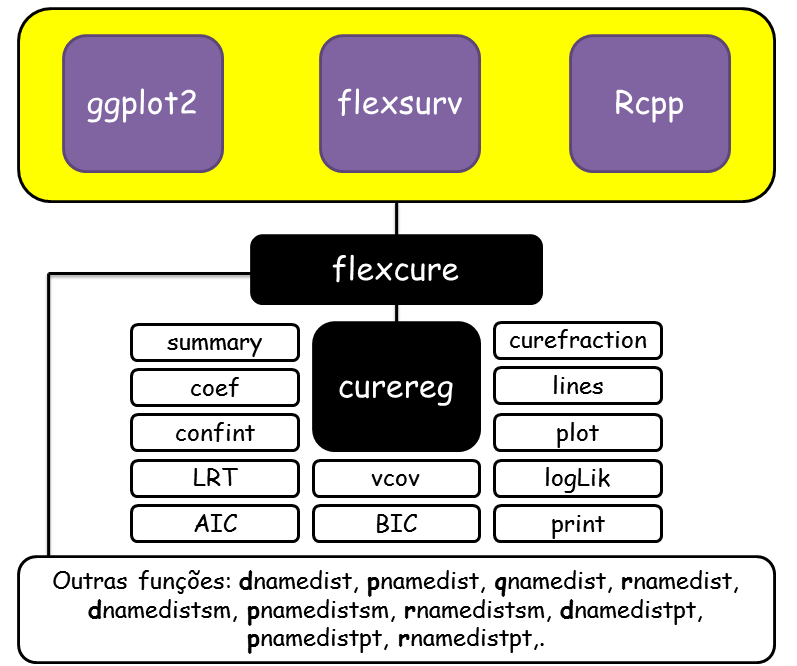

## Usando o pacote `flexcure`

## Instalação

```r
# Instalando o pacote devtools para usar a função install_github
# install.packages(devtools)

# Carregando o pacote devtools:
# require(devtools)

# Instalando o pacote flexcure:
# install_github("rumenick/flexcure")

# Carregando o pacote flexcure:
require(flexcure)
```

Repositório: https://github.com/Rumenick/flexcure

## A função `curereg`

```r
curereg(formula, cureformula = ~1, data, weights, timedist = "moeev",
        ncausedist = "poisson", subset, na.action, inits, method = "SANN", ...)
```

## Ajustando dados de melanoma cutâneo (IBRAHIM, CHEN E SINHA, 2001)

```r
# Carregando o conjunto de dados:
df <- read.table("Melanoma.txt", header = TRUE)[,1:3]
str(df)
```

```
## 'data.frame':    417 obs. of  3 variables:
##  $ t : num  0.723 6.3 6.623 3.472 7.012 ...
##  $ c : int  1 0 0 1 0 0 0 1 0 0 ...
##  $ x1: int  0 0 1 0 1 0 0 1 1 1 ...
```

```r
# Descrição das variáveis:
# t: tempo de sobrevivência (em anos);
# c: indicador de censura e
# x1: tratamento (0: grupo controle e 1: grupo tratado com Interferon alfa-2b)

# Ajustando o modelo de tempo de promoção Weibull:
fit0 <- curereg(formula = Surv(t, c)~1, cureformula = ~1, data = df,
                timedist = "ev", ncausedist = "poisson", method = "BFGS")
```

## Saída da função `curereg`

```r
fit0
```

```
## Call:
## curereg(formula = Surv(t, c) ~ 1, cureformula = ~1, data = df,
##     timedist = "ev", ncausedist = "poisson", method = "BFGS")
## Distribution: Extreme value (or Weibull) promotion time model
## Coefficients:
## Cure probability model:
## (Intercept)
##     -0.3933
##
## Failure time distribution model:
## (Intercept)   Log(sigma)
##      0.9342      -0.5346
##
## n = 417, Events: 185, Censored: 232
## Log-likelihood = -527.3982
## AIC = 1060.796
```

## Resumo da função `curereg`

```r
summary(fit0)
```

```
## Call:
## curereg(formula = Surv(t, c) ~ 1, cureformula = ~1, data = df,
##     timedist = "ev", ncausedist = "poisson", method = "BFGS")
## Distribution: Extreme value (or Weibull) promotion time model
##
## Cure probability model:
##              Estimate  Std. Error  Z value  Pr(>|Z|)
## (Intercept)   -0.3933     0.08483   -4.636  1.78e-06
##
## Failure time distribution model:
##              Estimate  Std. Error  Z value  Pr(>|Z|)
## (Intercept)    0.9342     0.07230   12.921  0.00e+00
## Log(sigma)    -0.5346     0.06596   -8.106  2.22e-16
##
## n = 417, Events: 185, Censored: 232
## Log-likelihood = -527.3982
## AIC = 1060.796
```

## Extraindo os coeficientes

```r
# Extraindo os coeficientes do modelo:
# Geral:
coef(fit0)
```

```
## $coef.cure
## (Intercept)
##  -0.3932521
##
## $coef.time
## (Intercept)  Log(sigma)
##   0.9341750  -0.5346292
```

```r
# Associados a fração de cura:
# coef(fit0, terms = "cure")

# Associados aos tempos:
# coef(fit0, terms = "time")
```

## Estimando a função de sobrevivência e a fração de curados

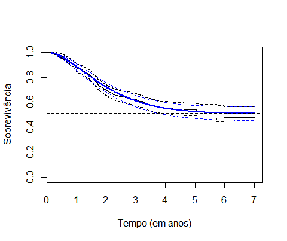

```r
plot(fit0, xlab = "Tempo (em anos)", ylab = "Sobrevivência", mark.time = FALSE, col = "blue")
cure <- curefraction(fit0); abline(h = cure, lty= 2)
```

## Ajustando o modelo com a covariável tratamento

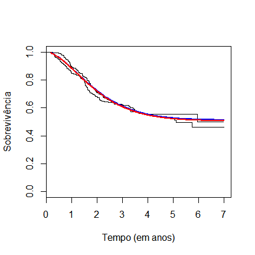

```r
fit1 <- curereg(formula = Surv(t, c)~1, cureformula = ~factor(x1), data = df,
                timedist = "ev", ncausedist = "poisson", method = "BFGS")

plot(fit1, xlab = "Tempo (em anos)", ylab = "Sobrevivência", mark.time = FALSE, col = c("blue","red"))
```

## Resumo do `fit1`

```r
summary(fit1)
```

```
## Call:
## curereg(formula = Surv(t, c) ~ 1, cureformula = ~factor(x1),
##     data = df, timedist = "ev", ncausedist = "poisson", method = "BFGS")
## Distribution: Extreme value (or Weibull) promotion time model
##
## Cure probability model:
##              Estimate  Std. Error  Z value   Pr(>|Z|)
## (Intercept)  -0.40217      0.1143  -3.5194  0.0002163
## factor(x1)1   0.01728      0.1472   0.1174  0.4532888
##
## Failure time distribution model:
##              Estimate  Std. Error  Z value  Pr(>|Z|)
## (Intercept)    0.9343     0.07233   12.917  0.00e+00
## Log(sigma)    -0.5346     0.06596   -8.104  2.22e-16
##
## n = 417, Events: 185, Censored: 232
## Log-likelihood = -527.3913
## AIC = 1062.783
```

## Teste da razão de verossimilhanças

```r
# Gerando os dados:
set.seed(1248)
df <- rmoeevsm(n = 500, mu = 0, sigma = 1, alpha = 1, theta = .2, control = 15)
str(df)
```

```
## List of 3
##  $ time  : num [1:500] 0.411 1.243 0.304 0.534 8.395 ...
##  $ status: num [1:500] 1 1 1 1 0 1 1 0 1 1 ...
##  $ ncause: int [1:500] 1 1 1 1 0 1 1 0 1 1 ...
```

```r
# Model under the null hypothesis (sigma = 1)
fits <- curereg(Surv(time, status) ~ 1, cureformula = ~ 1,
data = df, timedist = "moee", ncausedist = "bernoulli",
method = "BFGS")

# Model under the alternative hypothesis (sigma != 1)
fitg <- curereg(Surv(time, status) ~ 1, cureformula = ~ 1,
data = df, timedist = "moeev", ncausedist = "bernoulli",
method = "BFGS")
```

## Teste da razão de verossimilhanças

```r
# Realizando o teste:
LRT(fits, fitg)
```

```
##       Likelihood ratio test
##
##  LRS = 0.3974, df = 1, p-value = 0.5284
##  alternative hypothesis:
##  Marshall-Olkin extended extreme value (or exponential) standart mixture model
##  is not suitable
```

## Referência

- SILVA, Rumenick Pereira da. **Modelos flexíveis de sobrevivência com fração de cura**: implementação computacional. 152 f. Dissertação (Mestrado em Matemática Aplicada e Estatística), Universidade Federal do Rio Grande do Norte, Natal–RN, 2015.

e–mail: rumenickps@gmail.com

## Obrigado!!! :)